# Data Science Skills Project

Joby John and Peter Kowalchuk

October 14, 2018

# Open Skill data science skills analysis

Use data in Open Skills web site to find job titles with Data Science skills.  
Data from site to be used is clean_title_count

Use tidy workflow to produce analysis:

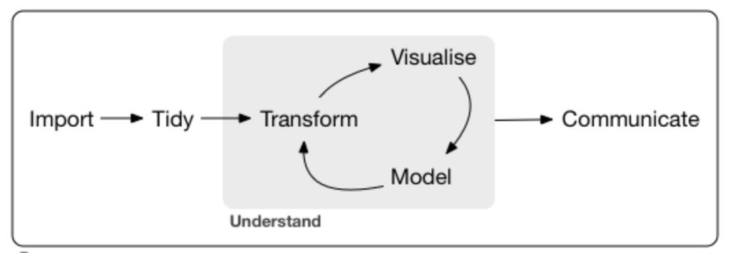

## Libraries

```r
library(RCurl)
library(dplyr)
library(tidyr)
library(rvest)
library(stringr)
library(ggplot2)
library(kableExtra)
library(RMySQL)
library(wordcloud2)
```

## Import

### Get list of csv files to import from Open Skills website

```r
csvFiles<-read_html("https://open-skills-datasets.s3-us-west-2.amazonaws.com/") %>% html_nodes("key") %>% html_text() %>% str_extract("cleaned_title_count/[:print:]+") %>% str_extract("[0-9]+Q[1-4].csv")
csvFiles<-csvFiles[!is.na(csvFiles)]
csvFiles %>% kable(align = 'c') %>% kable_styling() %>% scroll_box(width = "300px",height="400px") %>% kable_styling(position = "center")
```

| x |
| --- |
| 2011Q1.csv |
| 2011Q2.csv |
| 2011Q3.csv |
| 2011Q4.csv |
| 2012Q1.csv |
| 2012Q2.csv |
| 2012Q3.csv |
| 2012Q4.csv |
| 2013Q1.csv |
| 2013Q2.csv |
| 2013Q3.csv |
| 2013Q4.csv |
| 2014Q1.csv |
| 2014Q2.csv |
| 2015Q1.csv |
| 2016Q1.csv |
| 2016Q2.csv |
| 2016Q3.csv |
| 2016Q4.csv |
| 2017Q1.csv |

### Load last 4 csv files - last year worth of data

```r
out<-vector()
for (i in 0:3) {
  url<-paste("https://open-skills-datasets.s3-us-west-2.amazonaws.com/cleaned_title_count/",csvFiles[length(csvFiles)-i],sep="")
  x<-getURL(url)
  out<-rbind(out,read.csv(textConnection(x)))
}
dataTable<-tbl_df(out)
head(dataTable,n=20) %>% kable() %>% kable_styling() %>% scroll_box(width = "910px",height="400px")
```

| title | counts_total | skills_1 | skills_2 | skills_3 | skills_4 | skills_5 | skills_6 | skills_7 | skills_8 | skills_9 | skills_10 | soc_code_common_1 | soc_code_common_2 | soc_code_common_total | soc_code_top_1 | soc_code_top_2 | soc_code_top_total | soc_code_given_1 | soc_code_given_2 | soc_code_given_total |
| --- | --- | --- | --- | --- | --- | --- | --- | --- | --- | --- | --- | --- | --- | --- | --- | --- | --- | --- | --- | --- |
|  | 1 |  |  |  |  |  |  |  |  |  |  | 39-9032.00 |  | 1 | 13-1071.00 |  | 1 | 35-2014.00 | NA | 1 |
| rsaf language training elt instructors | 2 | c | reduce | english language |  |  |  |  |  |  |  | 25-1123.00 |  | 1 | 27-3031.00 | 21-1093.00 | 2 |  | NA | 1 |
| integrator | 2 | troubleshooting | skill | red hat enterprise linux | linux | design |  |  |  |  |  | 15-1142.00 |  | 1 | 15-1122.00 | 15-1143.00 | 2 |  | NA | 1 |
| correctional officer | 1 | transportation | brakes |  |  |  |  |  |  |  |  | 33-1012.00 |  | 1 | 29-2012.00 |  | 1 | 33-3012.00 | NA | 1 |
| store all positions | 2 | time management |  |  |  |  |  |  |  |  |  | 13-1199.00 | 51-9151.00 | 2 | 43-4161.00 | 43-4051.03 | 2 |  | NA | 1 |
| head of office | 2 | writing | forth |  |  |  |  |  |  |  |  | 11-2022.00 | 11-3021.00 | 2 | 13-1151.00 | 11-3021.00 | 2 |  | NA | 1 |
| security positions | 1 | rules | closedcircuit tv cameras | security cameras | bulletproof vests | surveillance cameras | alarms |  |  |  |  | 33-3051.01 |  | 1 | 33-3051.01 |  | 1 |  | NA | 1 |
| sr manager event communications | 1 | speaking | writing | forth |  |  |  |  |  |  |  | 11-2031.00 |  | 1 | 11-2011.00 |  | 1 | 11-2021.00 | NA | 1 |
| assistant director of engineering and construction | 1 | ada | mechanical | levels | impact |  |  |  |  |  |  | 11-9041.00 |  | 1 | 17-2141.00 |  | 1 |  | NA | 1 |
| scheduling coordinator | 3 | microsoft office |  |  |  |  |  |  |  |  |  | 31-1014.00 | 29-2061.00 | 2 | 11-9111.00 | 41-4011.00 | 3 | 43-5061.00 | NA | 1 |
| systems engineer fair | 1 | skill |  |  |  |  |  |  |  |  |  | 17-2071.00 |  | 1 | 17-2141.00 |  | 1 |  | NA | 1 |
| school bus driver | 2 | skill | transportation | route |  |  |  |  |  |  |  | 25-2012.00 |  | 1 | 25-2052.00 | 25-9041.00 | 2 | 53-3022.00 | NA | 1 |
| systems analyst | 1 | skill | c | simulation software | mathematics | mechanical | physics | science | design |  |  | 13-1111.00 |  | 1 | 15-1121.00 |  | 1 | 15-1121.00 | NA | 1 |
| warehouser | 1 | trucks | pallet jacks | forklifts | sweepers |  |  |  |  |  |  | 33-3051.01 |  | 1 | 49-9071.00 |  | 1 | 49-9071.00 | NA | 1 |
| cloud solution architect | 2 | redmine | c | programming | python | visualization | javascript | puppet | apache tomcat | stencils | oracle | 15-1132.00 | 15-1121.00 | 2 | 15-1132.00 | 15-1143.00 | 2 | 15-1199.02 | NA | 1 |
| insemination crew worker | 4 | speaking | self | personal protective equipment |  |  |  |  |  |  |  | 43-5061.00 | 27-2011.00 | 4 | 35-3021.00 | 37-2011.00 | 4 |  | NA | 1 |
| product support sales representative | 2 | stamina |  |  |  |  |  |  |  |  |  | 41-4012.00 |  | 1 | 41-4011.00 | 41-2031.00 | 2 |  | NA | 1 |
| direct support professional team leader | 1 |  |  |  |  |  |  |  |  |  |  | 29-1181.00 |  | 1 | 15-1122.00 |  | 1 |  | NA | 1 |
| data scientist | 1 | skill | science | git | python | mathematics | r | derive |  |  |  | 15-1134.00 |  | 1 | 17-2112.00 |  | 1 | 15-1111.00 | NA | 1 |
| part bus driver commercial drivers license | 1 |  |  |  |  |  |  |  |  |  |  | 33-3051.01 |  | 1 | 53-3022.00 |  | 1 |  | NA | 1 |

## Tidy

### Build long tables for skills and jobs

```r
#Get skills
skills <- dataTable %>%select( starts_with('skill') )    %>%
  gather(3:10,  value = "skill") %>%
  select( starts_with('skill')) %>%
  distinct() %>%
  filter(skill != '')
#Get job titles
jobs <- dataTable %>%select( 1)  %>%
  filter(title != '')   %>%
  distinct()
 names(jobs)<-c('job_name')
 names(skills) <- c('skill_name')
head(jobs,n=20) %>% kable() %>% kable_styling() %>% scroll_box(width = "910px",height="400px")
```

| job_name |
| --- |
| rsaf language training elt instructors |
| integrator |
| correctional officer |
| store all positions |
| head of office |
| security positions |
| sr manager event communications |
| assistant director of engineering and construction |
| scheduling coordinator |
| systems engineer fair |
| school bus driver |
| systems analyst |
| warehouser |
| cloud solution architect |
| insemination crew worker |
| product support sales representative |
| direct support professional team leader |
| data scientist |
| part bus driver commercial drivers license |
| senior engineer |

```r
head(skills,n=20) %>% kable() %>% kable_styling() %>% scroll_box(width = "910px",height="400px")
```

| skill_name |
| --- |
| c |
| troubleshooting |
| transportation |
| time management |
| writing |
| rules |
| speaking |
| ada |
| microsoft office |
| skill |
| trucks |
| redmine |
| stamina |
| hoists |
| visualization |
| meat slicers |
| sales and marketing |
| negotiation |
| coordination |
| trash bags |

### Save skills and jobs to DB

```r
con = dbConnect(MySQL(), user='data607p3', password='data607p3', dbname='job_skills', host='localhost')

########################################################################
#only run this once otherwise tables will have duplicate data
#RMySQL::dbWriteTable(con, 'jobs', jobs, append = TRUE, row.names = FALSE)
#RMySQL::dbWriteTable(con, 'skills', skills, append = TRUE, row.names = FALSE)
#########################################################################
```

### Read jobs and skills back

We are using auto increment id column for primary key so we need to read the tables back to do the mapping table

```r
job_db <- dbReadTable(con, 'jobs')
skills_db<- dbReadTable(con, 'skills')
head(job_db,n=20) %>% kable() %>% kable_styling() %>% scroll_box(width = "910px",height="400px")
```

| job_id | job_name |
| --- | --- |
| 1 | rsaf language training elt instructors |
| 2 | integrator |
| 3 | correctional officer |
| 4 | store all positions |
| 5 | head of office |
| 6 | security positions |
| 7 | sr manager event communications |
| 8 | assistant director of engineering and construction |
| 9 | scheduling coordinator |
| 10 | systems engineer fair |
| 11 | school bus driver |
| 12 | systems analyst |
| 13 | warehouser |
| 14 | cloud solution architect |
| 15 | insemination crew worker |
| 16 | product support sales representative |
| 17 | direct support professional team leader |
| 18 | data scientist |
| 19 | part bus driver commercial drivers license |
| 20 | senior engineer |

```r
head(skills_db,n=20) %>% kable() %>% kable_styling() %>% scroll_box(width = "910px",height="400px")
```

| skill_id | skill_name |
| --- | --- |
| 1 | c |
| 2 | troubleshooting |
| 3 | transportation |
| 4 | time management |
| 5 | writing |
| 6 | rules |
| 7 | speaking |
| 8 | ada |
| 9 | microsoft office |
| 10 | skill |
| 11 | trucks |
| 12 | redmine |
| 13 | stamina |
| 14 | hoists |
| 15 | visualization |
| 16 | meat slicers |
| 17 | sales and marketing |
| 18 | negotiation |
| 19 | coordination |
| 20 | trash bags |

### Tidy & Transform job to skills mapping then save it to db

```r
job_skills <-  dataTable   %>%
  gather(3:10,  value = "skill_name", key="job_name") %>%
  filter(skill_name != '') %>%
  filter(title != '') %>%
  select(title, skill_name)%>%
  as.data.frame()
names(job_skills) <- c('job_name','skill_name')
head(job_skills,n=20) %>% kable() %>% kable_styling() %>% scroll_box(width = "910px",height="400px")
```

| job_name | skill_name |
| --- | --- |
| rsaf language training elt instructors | c |
| integrator | troubleshooting |
| correctional officer | transportation |
| store all positions | time management |
| head of office | writing |
| security positions | rules |
| sr manager event communications | speaking |
| assistant director of engineering and construction | ada |
| scheduling coordinator | microsoft office |
| systems engineer fair | skill |
| school bus driver | skill |
| systems analyst | skill |
| warehouser | trucks |
| cloud solution architect | redmine |
| insemination crew worker | speaking |
| product support sales representative | stamina |
| data scientist | skill |
| senior engineer | skill |
| network engineer i | troubleshooting |
| cdla truck drivers | trucks |

```r
# save jobs_skills mapping. we are doing this because we have auto increment private keys.
job_skills_map <- job_skills %>%
                  inner_join(skills_db )  %>%
                  inner_join(job_db )   %>%
                  select(job_id, skill_id) %>%
                  distinct()
```

# Question 1 - What are the most important skills in Data Science?

## Transform

Filter table for data science titles only

```r
job_skills_dataScience<-filter(job_skills,str_detect(job_name,"data scientist"))
head(job_skills_dataScience,n=20) %>% kable() %>% kable_styling() %>% scroll_box(width = "910px",height="400px")
```

| job_name | skill_name |
| --- | --- |
| data scientist | skill |
| data scientist intern | r |
| data scientist intern tech | r |
| data scientist | science |
| data scientist senior | c |
| senior data scientist financial services analytics | rules |
| data scientist associate manager | levels |
| senior data scientist secret ft job | levels |
| machine learning analyst data scientist job | mathematics |
| etl data scientist | levels |
| chief data scientist | levels |
| principal data scientist | impact |
| geospatial abi analyst data scientist | writing |
| data scientist intern | design |
| data scientist sr consultant | impact |
| prospective data scientist | biology |
| data scientist financial services analytics | rules |
| data scientist data analytics | levels |
| data scientist job | r |
| data scientist | science |

Create a vector with all skills

```r
skillsDataScience<-pull(job_skills_dataScience,'skill_name')
skillsDataScience<-table(skillsDataScience)
head(skillsDataScience,n=10) %>% kable() %>% kable_styling() %>% scroll_box(width = "910px",height="400px")
```

| skillsDataScience | Freq |
| --- | --- |
| 23 | 2 |
| apache hadoop | 4 |
| biology | 1 |
| c | 18 |
| chemistry | 2 |
| cmake | 5 |
| collectors | 2 |
| compliance software | 1 |
| coordination | 3 |
| critical thinking | 7 |

## Visualize

Order data then visualize using ggplot

Also we plot a word soup using wordcloud2 package

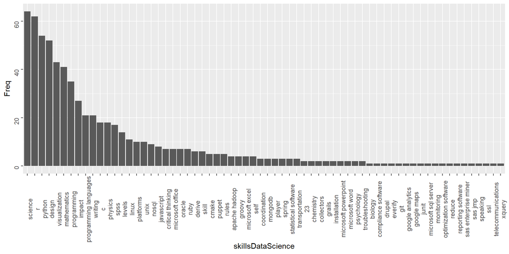

```r
skillsDataScienceOrdered<-skillsDataScience %>% as.data.frame() %>% tbl_df()
skillsDataScienceOrdered$skillsDataScience <- factor(skillsDataScienceOrdered$skillsDataScience,levels=skillsDataScienceOrdered$skillsDataScience[order(-skillsDataScienceOrdered$Freq)])

ggplot(skillsDataScienceOrdered,aes(x=skillsDataScience,y=Freq))+geom_bar(stat="identity")+theme(axis.text = element_text(angle=90))
```

```r
wordcloud2(skillsDataScienceOrdered,shuffle = TRUE,size = .5,gridSize = 15)
```

[interactive chart not shown]

# Question 2 - What Data Science job tittles require the most skills?

## Transform

Same as in question 1 we filter our long tidy table for data science titles only, but this time we group them

```r
job_skills_dataScience<-filter(job_skills,str_detect(job_name,"data scientist")) %>% group_by(job_name) %>% count()
head(job_skills_dataScience,n=20) %>% kable() %>% kable_styling() %>% scroll_box(width = "910px",height="400px")
```

| job_name | n |
| --- | --- |
| data scientist | 31 |
| data scientist intern | 18 |
| data scientist intern tech | 10 |
| chief data scientist | 12 |
| cs data scientist mid | 8 |
| data scientist analyst staff | 8 |
| data scientist analyst statistician | 7 |
| data scientist associate manager | 8 |
| data scientist data analytics | 13 |
| data scientist financial services analytics | 16 |
| data scientist insight studio consulting mit | 8 |
| data scientist insight studio consulting northeastern | 8 |
| data scientist intern of champagne | 5 |
| data scientist job | 14 |
| data scientist manager | 12 |
| data scientist mid | 16 |
| data scientist senior | 16 |
| data scientist sr consultant | 2 |
| devops data scientist senior | 16 |
| etl data scientist | 8 |

## Visualize

We order data and visualize using ggplot

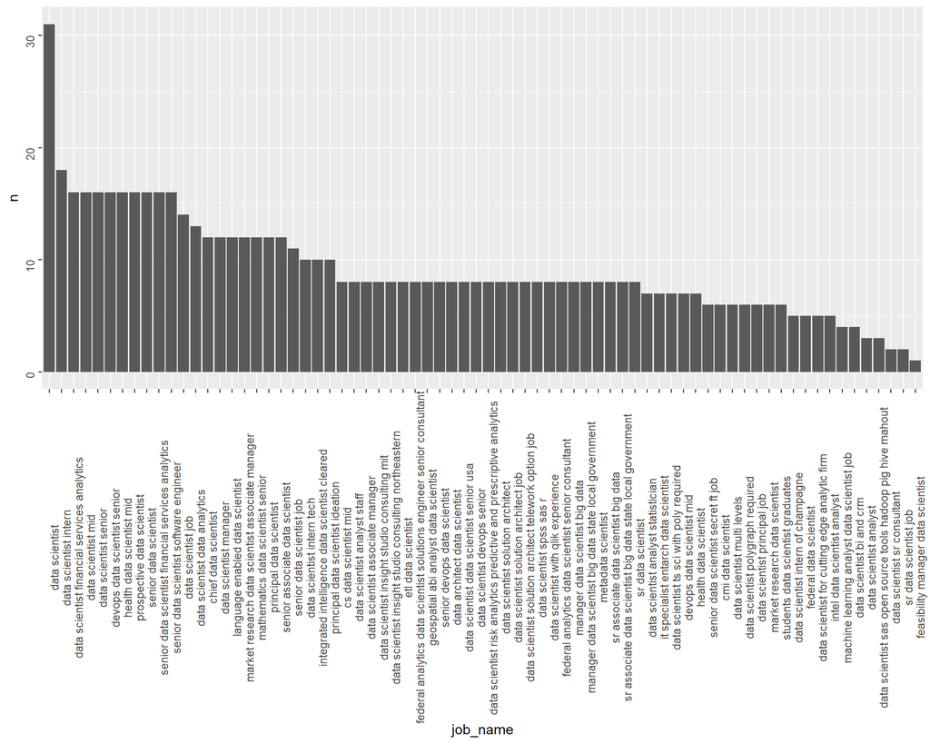

```r
skillsDataScienceOrdered<-job_skills_dataScience
skillsDataScienceOrdered$job_name <- factor(skillsDataScienceOrdered$job_name,levels=skillsDataScienceOrdered$job_name[order(-skillsDataScienceOrdered$n)])

ggplot(skillsDataScienceOrdered,aes(x=job_name,y=n))+geom_bar(stat="identity")+theme(axis.text = element_text(angle=90))
```

# Question 3 - What other job titles have similar skills to Data Science?

## Transform

Once again we filter data scientist, and then we do a join with all other job names to find those with similar skills

```r
job_skills_dataScience<-filter(job_skills,str_detect(job_name,"data scientist"))
job_skills_dataScience<-job_skills_dataScience %>% filter(skill_name!='skill')
same_skills<-job_skills %>% right_join(job_skills_dataScience,by='skill_name') %>% subset(!(job_name.x %in% job_skills_dataScience$job_name)) %>% group_by(job_name.x) %>% count()
```

## Visualize

We order and visualize the data using ggplot

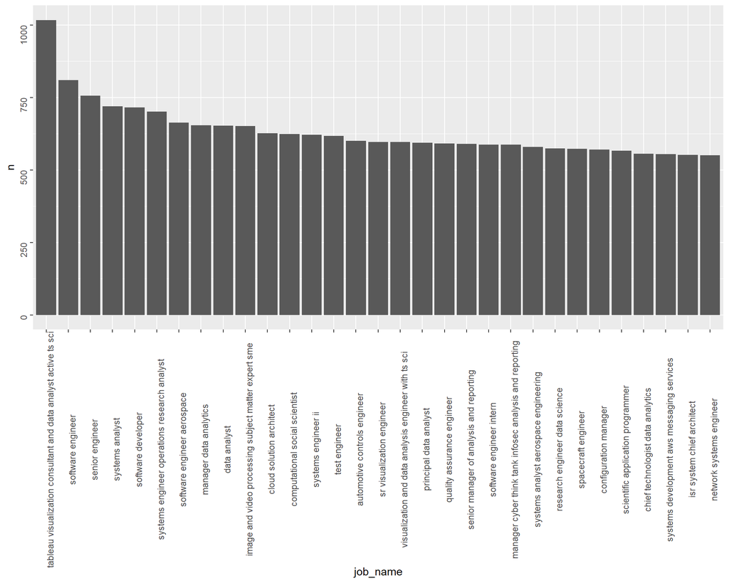

```r
same_skills_Ordered<-same_skills %>% filter(n>550) %>% as.data.frame() %>% tbl_df()
same_skills_Ordered$job_name <- factor(same_skills_Ordered$job_name.x,levels=same_skills_Ordered$job_name.x[order(-same_skills_Ordered$n)])

ggplot(same_skills_Ordered,aes(x=job_name,y=n))+geom_bar(stat="identity")+theme(axis.text = element_text(angle=90))
```

# Question 4 - What percentage of people have the skills to be a Data Scientist?

With this model, we test out 1000 random people and calculate a percentage

```r
skill_all<-job_skills$skill_name
skill_datascience<-job_skills_dataScience$skill_name
skill_not_datascience<-setdiff(job_skills$skill_name,skill_datascience)

number_of_data_sientists<-0
people_in_population<-1000
for (i in 1:people_in_population) {
  person<-skill_all[as.integer(runif(10,0,length(skill_all)))]
  if (length(setdiff(person,skill_datascience))>5) {
    #print(paste("Person",toString(i),"has skills to be a data scientist"))
    number_of_data_sientists<-number_of_data_sientists+1
  } else {
    #print(paste("Person",toString(i),"does not skills to be a data scientist"))
  }
}
proportion<-number_of_data_sientists/people_in_population*100
print(paste("The percentage of people with data science skills is: ",toString(proportion),"%",sep=""))
```

```
## [1] "The percentage of people with data science skills is: 10.2%"
```

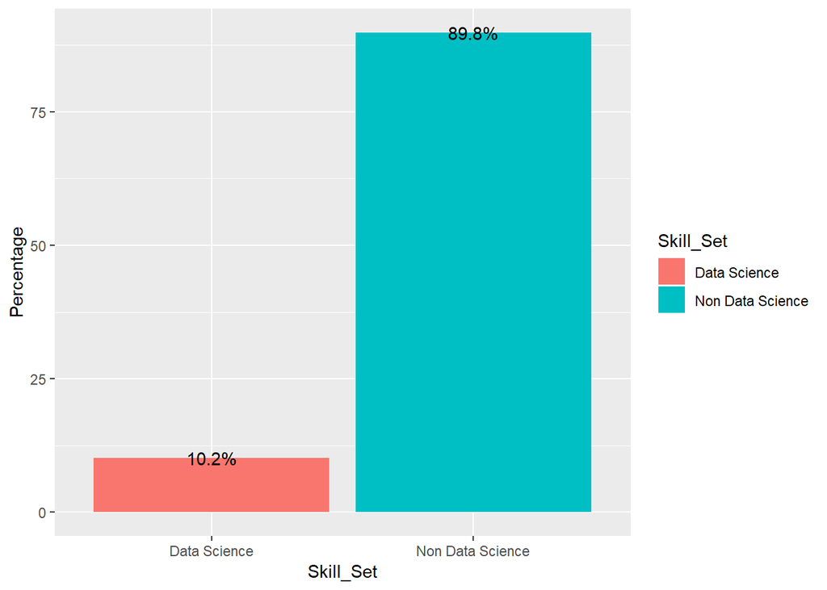

```r
result<-as.data.frame(c(100-proportion,proportion))
colnames(result)<-c("Percentage")
result$Skill_Set<-c("Non Data Science","Data Science")
ggplot(result,aes(y=Percentage,x=Skill_Set,fill=Skill_Set))+geom_bar(stat="identity")+geom_text(data=result,aes(y=Percentage,x=Skill_Set,label=paste(Percentage,"%",sep="")))
```